# Week 2 Tasks Solutions

In this task we will work with the dataset analysed and reported in the 2014 article from FiveThirtyEight.com entitled “41 Percent Of Fliers Think You’re Rude If You Recline Your Seat” [here](https://fivethirtyeight.com/features/airplane-etiquette-recline-seat/).

The data set is called `flying` and is in the `fivethirtyeight` package.

1. Write code to determine the proportion of respondents in the survey that responded with “Very” when asked if a passenger reclining their seat was rude. You should determine this proportion across the different levels of `age` and `gender` resulting in a data frame of size 8 x 3. Assign the name `prop_very` to this calculated proportion in this aggregated data frame.

**Tip**

We can obtain proportions using the `mean()` function applied to logical values. For example suppose we want to count the proportion of “heads” in five tosses of a fair coin. If the results of the five tosses are stored in

`tosses <- c("heads", "tails", "tails", "heads", "heads")`

then we can use `mean(tosses == "heads")` to get the resulting answer of 0.6.

**Tip**

**I**ncluding the function `na.omit(TRUE)` in the ‘pipe’ (`|>`) removes all entries that are not complete whereas including the argument `na.rm=TRUE` in the `mean()` function removes just those entries where the relevant variable value is missing.

```r
#Further Task 2.1 Solution
two_group_prop_1 <- flying |>
  summarize(prop_very = mean(recline_rude=='Very', na.rm=TRUE),
            .by=c(gender,age))
#OR
two_group_prop_2 <- flying |>
  na.omit(TRUE) |>
  summarize(prop_very = mean(recline_rude=='Very'),
            .by = c(gender,age))
```

```r
#Compare the two summaries...
two_group_prop_1
```

```
# A tibble: 9 × 3
  gender age   prop_very
  <chr>  <ord>     <dbl>
1 <NA>   <NA>     0.0909
2 Male   30-44    0.0811
3 Male   18-29    0.152
4 Male   45-60    0.0804
5 Male   > 60     0.0606
6 Female > 60     0.129
7 Female 30-44    0.0541
8 Female 45-60    0.0410
9 Female 18-29    0.0860
```

```r
two_group_prop_2
```

```
# A tibble: 8 × 3
  gender age   prop_very
  <chr>  <ord>     <dbl>
1 Male   30-44    0.075
2 Male   18-29    0.140
3 Male   45-60    0.0658
4 Male   > 60     0.0455
5 Female > 60     0.135
6 Female 30-44    0.0548
7 Female 45-60    0.0353
8 Female 18-29    0.113
```

2. Using the aggregated data you’ve created, produce two bar plots (one stacked, the other side-by-side) to show the differences between the sexes of the proportion of people who believe reclining your seat is ‘very’ rude, within each age group.

What gender and age-range pairings have the highest and lowest proportions of thinking reclining airline seats are very rude in this survey?

What stands out to you as you review these proportions?

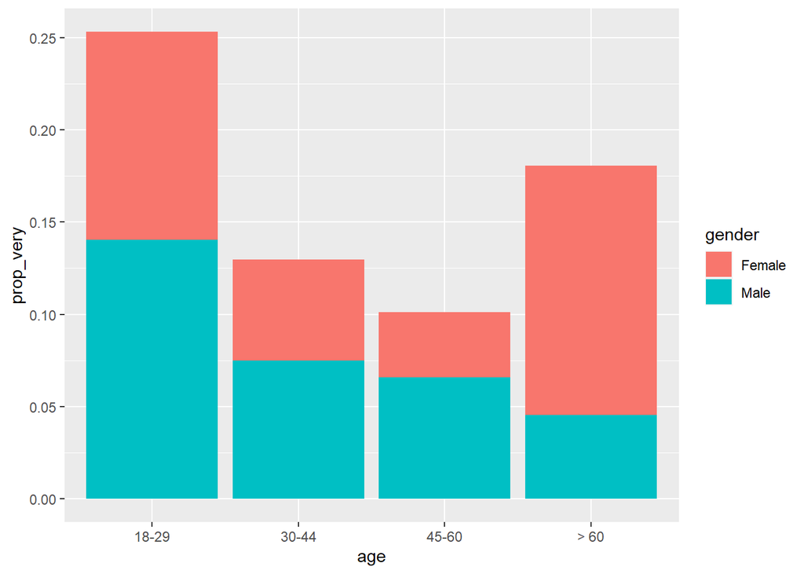

```r
#Further Task 2.2 Solution
ggplot(two_group_prop_2, aes(x=age,y=prop_very,fill=gender))+geom_col()
```

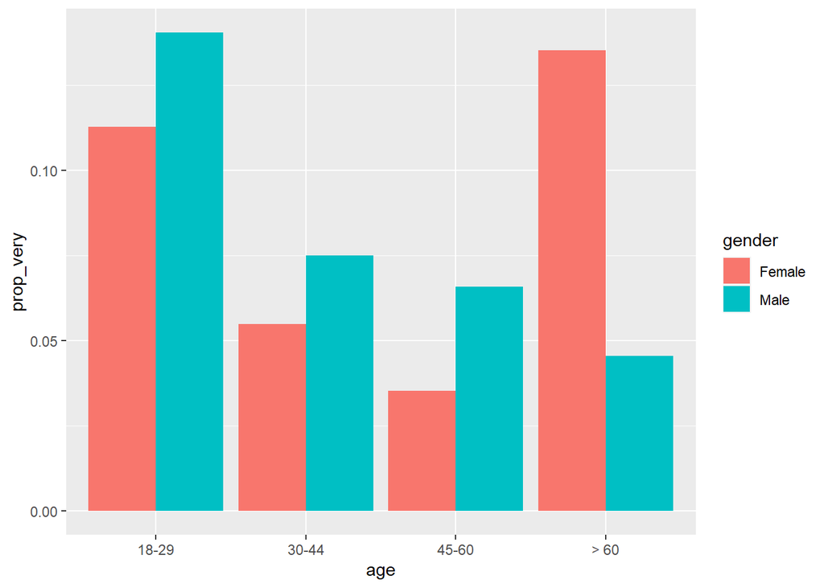

```r
ggplot(two_group_prop_2, aes(x=age,y=prop_very,fill=gender))+geom_col(position = "dodge")
```